# MB2-P - Multiverse Preregistration

Rmarkdown by Giulia Calignano, Marlena Mayer, Robert Hepach

2024-07-11

The following is based on the standard template as provided on aspredicted.org. This resource was very helpful: https://osf.io/byu28

## 1. Have any data been collected for this study already?

Yes, data have been collected as part of the Manybabies2 main study. The data collection was completed in 2023. The data is currently being curated by the main analysis team which will provide the raw data for the present study.

## 2. What’s the main question being asked or hypothesis being tested in this study?

**Main question and hypothesis 1: Does observing goal-incongruent events result in greater pupil dilation?**  
**Children’s baseline-corrected changes in pupil dilation will systematically vary as a function of the two experimental factors ‘condition’ (knowledge; ignorance) and ‘outcome’ (congruent; incongruent).**

If children show a

- perceptual familiarity preference, pupil dilation will increase in response to the familiar outcome, i.e., the bear approaches the mouse’s box. This would be evident in a main effect of outcome (Hypothesis 1.1).
- perceptual novelty preference, pupil dilation will increase in response to the novel outcome, i.e., the bear approaches the empty box. This would be evident in a main effect of outcome. (Hypothesis 1.2)
- conceptual familiarity preference, pupil dilation will increase in response to the bear approaching the mouse’s box in the knowledge condition only. This would be evident in an interaction effect of outcome and condition. (Hypothesis 1.3)
- conceptual novelty preference, pupil dilation will be increased in response to the bear approaching the empty box in the knowledge condition only. This would be evident in an interaction effect of outcome and condition. (Hypothesis 1.4)

**Main question 2: Does observing goal-incongruent events result in longer cumulative looking time?** We will test the same hypotheses as for **Main question 1**.

**Main question and hypothesis 3:**

**Does increased pupil dilation in response to goal-incongruent events reflect a surprise response above and beyond it reflecting a novelty response?**  
**Children’s pupil dilation (and cumulative looking time) in response to the outcome will systematically vary with the degree of anticipatory looking before the outcome. This would be evidence for changes in pupil dilation (and cumulative looking time) reflecting a surprise response.**

## 3. Describe the key dependent variable(s) specifying how they will be measured.

The main dependent variables are

- the **baseline-corrected change in pupil dilation** for the second test trial only. We will follow the preprocessing of the main study and work with those trials that were included in the main analyses for MB2. We will only use trials (i.e., the second test trial) which were included in the main MB2-analysis, i.e., wequire children to have contributed data for both test trial in the main analysis. The information typically used for pre-processing pupil dilation data: PupilLeft(mm), PupilRight(mm), StimuliName, GazeX, GazeY, GazeEventType, RecordingTimeStamp.
- The **pupil dilation** across a multiverse of preprocessing steps of pupil size data employ the multiverse approach shown in detail below with reproducible R-code (based on Calignano et al., 2023) on simulated data based on MB2 data dictionary.
- **Total looking time in a fixed time window**, i.e., 30 sec after the bear exits the tubes (following e.g., Dörrenberg et al., 2018). This is calculated for the second test trial only.
- **Standard VoE infant controlled measure**, i.e., looking time until infant looks away for 2 seconds (see Baillargeon et al., 2018 commentary *→ check details with Renee Baillargeon, Gergo Csibra and other VoE experts*). These analyses include looking at the whole screen (maximum AOI).
- The **degree of anticipation**, that is the time children took to fixate the ‘correct’ AOI. The measure will be provided by the main MB2-analysis. -> AL score (proportion looking to correct AOI/ looking to correct + incorrect AOI).

## Data simulation

To facilitate the pre-registration of our data preprocessing and analysis strategies, the accompanying R-script details a procedure for creating a simulated dataset that mirrors the characteristics of our anticipated data. This data simulation technique is instrumental in devising our data handling and analysis plans prior to actual data analysis The simulation includes generating random strings for identifiers and categorical variables, producing numeric data within defined ranges, managing missing values, and computing correlations. By examining the properties of the simulated dataset, we can ensure our analysis plan is robust and well-equipped to manage the complexities of the real dataset./

Of note the dataset includes only the second trial and the two conditions x two outcome are presented in a long form with each of the *N* = 946 participants having time-series data for the four possible solutions./

Here the description of the dataset generated by the R-code:

- **participant_id**: A unique identifier for each participant, generated as a random string. Each participant has a unique ID to distinguish them in the dataset.
- **age_cohort**: A randomly generated string intended to categorize participants into different age cohorts.
- **t**: A numeric variable representing a timestamp or duration, generated within a specified range and with a possibility of missing values (NA).
- **x and y**: Numeric variables generated within specified ranges, intended to represent coordinates or other measurements, with a possibility of missing values.
- **pupil_left and pupil_right**: Numeric variables representing measurements of the left and right pupil sizes, respectively. These variables are generated with a specified correlation and then rescaled to a specific range.
- **lab_id**: A randomly generated string serving as a unique identifier for the lab or testing location.
- **conditions**: A categorical variable with two levels, i.e. “knowledge” and “ignorance”
- **outcomes**: A categorical variable with two levels, i.e. “incongruent” and “congruent”

```r
# Install and load required packages
if (!require('dplyr')) install.packages('dplyr')
if (!require('tidyr')) install.packages('tidyr')
library(dplyr)
library(tidyr)

set.seed(123)  # For reproducibility
rm(list = ls())
# Number of participants
num_participants <- 946
num_toddlers <- 453
num_adults <- 493

# Generate participant IDs
participant_id <- as.character(1:num_participants)

# Generate age cohorts
age_cohort <- c(rep("toddlers", num_toddlers), rep("adults", num_adults))

# Generate time vector t
time_per_condition <- seq(0, 10000, by=25)
n_times <- length(time_per_condition)
n_conditions <- 4  # Two levels for condition and two levels for outcome

# Generate x and y coordinates
generate_coordinates <- function(n, mean_X, sd_X, min_X, max_X, mean_Y, sd_Y, min_Y, max_Y) {
  data.frame(
    x = pmin(pmax(rnorm(n, mean_X, sd_X), min_X), max_X),
    y = pmin(pmax(rnorm(n, mean_Y, sd_Y), min_Y), max_Y)
  )
}

# Generate pupil diameters with correlation
generate_pupils <- function(n, mean_left, sd_left, min_left, max_left, mean_right, sd_right, min_right, max_right, cor) {
  pupils <- MASS::mvrnorm(n, mu = c(mean_left, mean_right),
                          Sigma = matrix(c(sd_left^2, cor * sd_left * sd_right,
                                           cor * sd_left * sd_right, sd_right^2),
                                         ncol = 2))
  pupils <- data.frame(
    pupil_left = pmin(pmax(pupils[,1], min_left), max_left),
    pupil_right = pmin(pmax(pupils[,2], min_right), max_right)
  )
  return(pupils)
}

# Generate conditions and outcomes
conditions <- c("knowledge", "ignorance")
outcomes <- c("incongruent", "congruent") # MSS: please check if this is correct! Does same refer to incongruent and empty to congruent as in choosing the same box and the empty box? But this would only be true for the ignorance condition but not for the knowledge condition, where the same box would be congruent and the empty box would be incongruent. I am somehow confused here.

# Generate lab_id
lab_id <- rep(1:16, each = num_participants / 16)

# Helper function to generate random strings
generate_string <- function(n, length) {
  replicate(n, paste0(sample(LETTERS, length, replace = TRUE), collapse = ""))
}

# Assemble the dataset
simulate_data <- do.call(rbind, lapply(1:num_participants, function(pid) {
  cohort <- age_cohort[pid]
  if (cohort == "toddlers") {
    coord <- generate_coordinates(n_times * n_conditions, 794.8072342, 436.464115, -4433, 4534, 508.3721513, 305.1846593, -2474, 2430)
    pupils <- generate_pupils(n_times * n_conditions, 3.835746142, 0.693875755, 0.846, 7.997, 3.851782931, 0.68683815, 0.982, 6.824, 0.8)
  } else {
    coord <- generate_coordinates(n_times * n_conditions, 870.0972924, 406.371616, -5328.666667, 4625, 584.0366922, 342.2138564, -4222, 3588)
    pupils <- generate_pupils(n_times * n_conditions, 3.41242103, 0.628702372, 0.518, 7.567, 3.416267459, 0.632454602, 0.846, 6.46, 0.8)
  }
  data.frame(
    participant_id = rep(participant_id[pid], n_times * n_conditions),
    age_cohort = rep(cohort, n_times * n_conditions),
    t = rep(time_per_condition, n_conditions),
    condition = rep(conditions, each = n_times * 2),
    outcome = rep(rep(outcomes, each = n_times), 2),
    x = coord$x,
    y = coord$y,
    pupil_left = pupils$pupil_left,
    pupil_right = pupils$pupil_right,
    event_num = sample(1:9, n_times * n_conditions, replace = TRUE),
    lab_id = rep(lab_id[pid], n_times * n_conditions),
    distance = runif(n_times * n_conditions, 0, 0),
    target_side = generate_string(n_times * n_conditions, 2),
    bear_not_visible_ms = runif(n_times * n_conditions, 0, 31264),
    point_of_disambiguation = runif(n_times * n_conditions, 0, 35499),
    screen_width = sample(c(1280, 1920), n_times * n_conditions, replace = TRUE),
    screen_height = sample(c(720, 1080), n_times * n_conditions, replace = TRUE),
    point_zero = generate_string(n_times * n_conditions, 1),
    x_screen = runif(n_times * n_conditions, 0, 1930),
    y_screen = runif(n_times * n_conditions, 0, 1080),
    side = generate_string(n_times * n_conditions, 4),
    aoitype = generate_string(n_times * n_conditions, 5),
    aoi = generate_string(n_times * n_conditions, 15)
  )
}))
```

## The Multiverse forking paths of pupillometry preprocessing

The following script specifies the preprocessing and analysis steps of the multiverse approach applied to the MB2-P (see Calignano, Girardi, and Altoé, 2023).

- First Degree of freedom: Filtering of extreme yet plausible pupil values, i.e.<2mm, >8mm

```r
#### plausible value range ]2,8[ - from 1 to 2 DATASETS
simulate_data$age_cohort = as.factor(simulate_data$age_cohort)
simulate_data$average <- (simulate_data$pupil_left + simulate_data$pupil_right)/2
all <-simulate_data
all$step <- "implausible"
summary(all)
```

```
##  participant_id        age_cohort           t          condition
##  Length:1517384     adults  :790772   Min.   :    0   Length:1517384
##  Class :character   toddlers:726612   1st Qu.: 2500   Class :character
##  Mode  :character                     Median : 5000   Mode  :character
##                                       Mean   : 5000
##                                       3rd Qu.: 7500
##                                       Max.   :10000
##
##    outcome                x                 y             pupil_left
##  Length:1517384     Min.   :-1380.8   Min.   :-1062.4   Min.   :0.518
##  Class :character   1st Qu.:  550.6   1st Qu.:  327.1   1st Qu.:3.142
##  Mode  :character   Median :  836.1   Median :  545.7   Median :3.605
##                     Mean   :  834.9   Mean   :  548.1   Mean   :3.616
##                     3rd Qu.: 1120.4   3rd Qu.:  767.0   3rd Qu.:4.078
##                     Max.   : 2774.7   Max.   : 2262.6   Max.   :7.074
##
##   pupil_right      event_num         lab_id         distance target_side
##  Min.   :0.846   Min.   :1.000   Min.   : 1.00   Min.   :0   Length:1517384
##  1st Qu.:3.152   1st Qu.:3.000   1st Qu.: 4.75   1st Qu.:0   Class :character
##  Median :3.615   Median :5.000   Median : 8.50   Median :0   Mode  :character
##  Mean   :3.625   Mean   :4.998   Mean   : 8.50   Mean   :0
##  3rd Qu.:4.089   3rd Qu.:7.000   3rd Qu.:12.25   3rd Qu.:0
##  Max.   :6.824   Max.   :9.000   Max.   :16.00   Max.   :0
##                                  NA's   :3208
##  bear_not_visible_ms point_of_disambiguation  screen_width  screen_height
##  Min.   :    0.012   Min.   :    0.06        Min.   :1280   Min.   : 720.0
##  1st Qu.: 7825.981   1st Qu.: 8856.86        1st Qu.:1280   1st Qu.: 720.0
##  Median :15649.902   Median :17738.61        Median :1920   Median :1080.0
##  Mean   :15637.678   Mean   :17736.74        Mean   :1600   Mean   : 900.2
##  3rd Qu.:23440.982   3rd Qu.:26621.65        3rd Qu.:1920   3rd Qu.:1080.0
##  Max.   :31263.991   Max.   :35498.93        Max.   :1920   Max.   :1080.0
##
##   point_zero           x_screen            y_screen             side
##  Length:1517384     Min.   :   0.0005   Min.   :   0.0002   Length:1517384
##  Class :character   1st Qu.: 481.2856   1st Qu.: 270.5632   Class :character
##  Mode  :character   Median : 965.1901   Median : 540.1081   Mode  :character
##                     Mean   : 964.7291   Mean   : 540.1695
##                     3rd Qu.:1446.9044   3rd Qu.: 810.0647
##                     Max.   :1929.9998   Max.   :1079.9985
##
##    aoitype              aoi               average          step
##  Length:1517384     Length:1517384     Min.   :0.682   Length:1517384
##  Class :character   Class :character   1st Qu.:3.168   Class :character
##  Mode  :character   Mode  :character   Median :3.610   Mode  :character
##                                        Mean   :3.620
##                                        3rd Qu.:4.061
##                                        Max.   :6.900
##
```

```r
plausible <-simulate_data[simulate_data$average>2 & simulate_data$average<8,]
plausible$step <- "plausible"
summary(plausible)
```

```
##  participant_id        age_cohort           t          condition
##  Length:1508596     adults  :783705   Min.   :    0   Length:1508596
##  Class :character   toddlers:724891   1st Qu.: 2500   Class :character
##  Mode  :character                     Median : 5000   Mode  :character
##                                       Mean   : 5000
##                                       3rd Qu.: 7500
##                                       Max.   :10000
##
##    outcome                x                 y             pupil_left
##  Length:1508596     Min.   :-1380.8   Min.   :-1062.4   Min.   :1.304
##  Class :character   1st Qu.:  550.5   1st Qu.:  327.0   1st Qu.:3.152
##  Mode  :character   Median :  836.0   Median :  545.6   Median :3.610
##                     Mean   :  834.7   Mean   :  548.0   Mean   :3.626
##                     3rd Qu.: 1120.2   3rd Qu.:  766.9   3rd Qu.:4.082
##                     Max.   : 2774.7   Max.   : 2262.6   Max.   :7.074
##
##   pupil_right      event_num         lab_id          distance
##  Min.   :1.234   Min.   :1.000   Min.   : 1.000   Min.   :0
##  1st Qu.:3.161   1st Qu.:3.000   1st Qu.: 4.000   1st Qu.:0
##  Median :3.620   Median :5.000   Median : 8.000   Median :0
##  Mean   :3.636   Mean   :4.997   Mean   : 8.487   Mean   :0
##  3rd Qu.:4.092   3rd Qu.:7.000   3rd Qu.:12.000   3rd Qu.:0
##  Max.   :6.824   Max.   :9.000   Max.   :16.000   Max.   :0
##                                  NA's   :3184
##  target_side        bear_not_visible_ms point_of_disambiguation  screen_width
##  Length:1508596     Min.   :    0.012   Min.   :    0.06        Min.   :1280
##  Class :character   1st Qu.: 7826.182   1st Qu.: 8857.28        1st Qu.:1280
##  Mode  :character   Median :15648.977   Median :17737.97        Median :1920
##                     Mean   :15637.414   Mean   :17736.60        Mean   :1600
##                     3rd Qu.:23440.538   3rd Qu.:26620.44        3rd Qu.:1920
##                     Max.   :31263.991   Max.   :35498.93        Max.   :1920
##
##  screen_height     point_zero           x_screen            y_screen
##  Min.   : 720.0   Length:1508596     Min.   :   0.0005   Min.   :   0.0002
##  1st Qu.: 720.0   Class :character   1st Qu.: 481.2745   1st Qu.: 270.5625
##  Median :1080.0   Mode  :character   Median : 965.2679   Median : 540.1147
##  Mean   : 900.2                      Mean   : 964.7558   Mean   : 540.1762
##  3rd Qu.:1080.0                      3rd Qu.:1446.9936   3rd Qu.: 810.0659
##  Max.   :1080.0                      Max.   :1929.9998   Max.   :1079.9985
##
##      side             aoitype              aoi               average
##  Length:1508596     Length:1508596     Length:1508596     Min.   :2.000
##  Class :character   Class :character   Class :character   1st Qu.:3.177
##  Mode  :character   Mode  :character   Mode  :character   Median :3.615
##                                                           Mean   :3.631
##                                                           3rd Qu.:4.064
##                                                           Max.   :6.900
##
##      step
##  Length:1508596
##  Class :character
##  Mode  :character
##
##
##
##
```

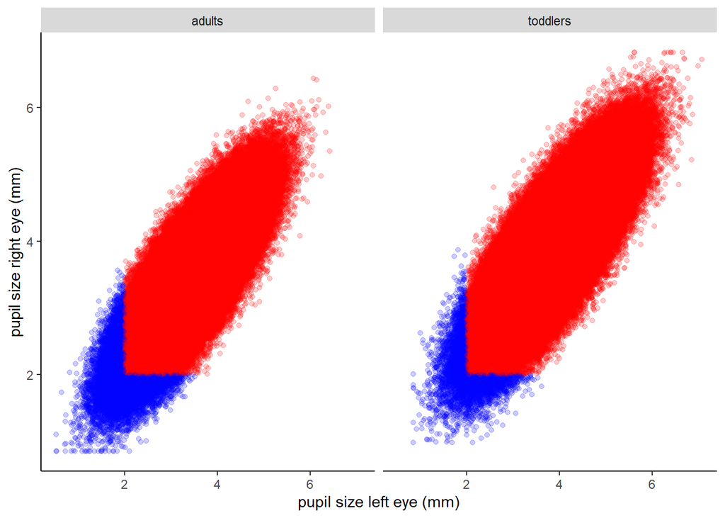

```r
all_plausible <- list(all, plausible)

all$pupil_left = as.numeric(as.character(all$pupil_left))
all$pupil_right = as.numeric(as.character(all$pupil_right))
all = all[all$pupil_left >0 & all$pupil_right>0,]

all %>% mutate(Color = ifelse(pupil_left <=2 | pupil_left >=8 | pupil_right <=2 | pupil_right >=8,"blue", "red")) %>%
  ggplot(aes(x = pupil_left, y= pupil_right, color = Color))+
  geom_point(alpha= 0.2)+ xlab("pupil size left eye (mm)") + ylab("pupil size right eye (mm)") +
  scale_color_identity() + theme(panel.grid.major = element_blank(), panel.grid.minor = element_blank(), panel.background = element_blank(), axis.line = element_line(colour = "black")) + facet_wrap("age_cohort")
```

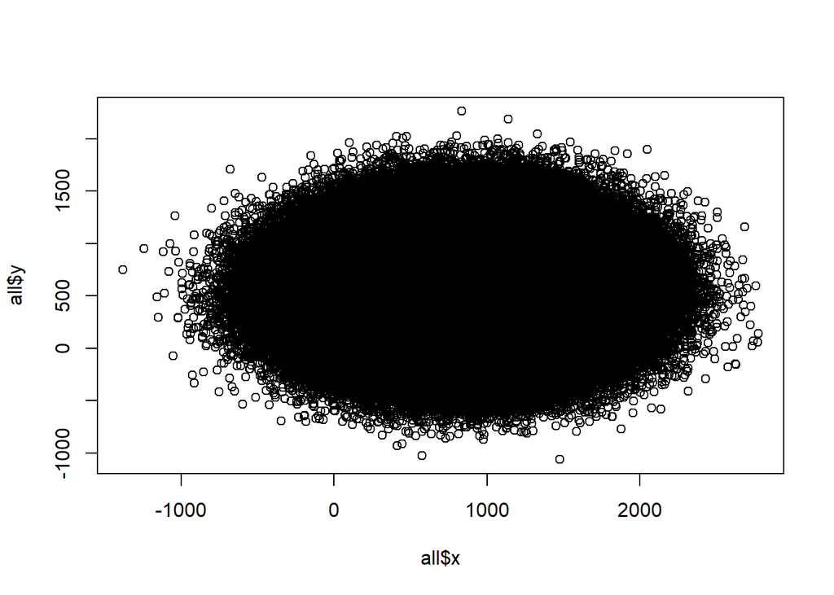

```r
plot(all$x,all$y)
```

- Second degree of freedom: We consider three possible baseline correction i.e. 5 seconds before the bear resolution vs 300 and 500 ms after the bear resolution. Correction is performed by subtracting the average pupil diameter from all subsequent values between, dividing those values by the average baseline, and averaging the baseline-corrected values vector.

```r
### median baseline from 2 to 6 DATASETS

### 3 median baselines, i.e., initial time window for each trial_num ,id, lab_id
### i.e. 5s before resolution vs 300 and 500 ms after bear resolution
library(plyr)
```

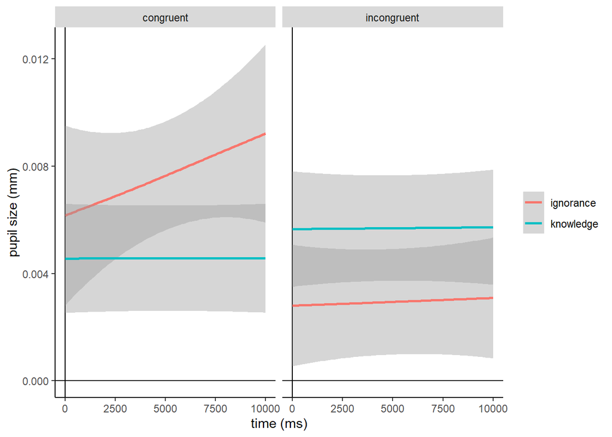

```r
universe_one <- all_plausible
#5ms baseline
    for (i in 1:2) {
         dg = 5
           universe_one[[i]]<-ddply(universe_one[[i]],.(participant_id,condition, outcome, lab_id),
                  transform,baseline = average - median(1:min(200:length(t))), na.rm = T)
           }


#300 ms baseline
universe_two <- all_plausible
  for (i in 1:2) {
    dg = 300
    universe_two[[i]]<-ddply(universe_two[[i]],.(participant_id, condition, outcome, lab_id),
                                     transform,baseline = average - median(average[1:min(206:length(t))]), na.rm = T)
}

#500 ms baseline
universe_three <-all_plausible
  for (i in 1:2) {
    dg = 500
    universe_three[[i]]<-ddply(universe_three[[i]],.(participant_id, condition, outcome, lab_id),
                                    transform,baseline = average - median(average[1:min(212:length(t))]), na.rm = T)
}

#multiverse
multiverse <- list(universe_one, universe_two, universe_three)

#plot
library(gridExtra)
data_summary <- function(x) {
  m <- median(x)
  ymin <- m-sd(x)
  ymax <- m+sd(x)
  return(c(y=m,ymin=ymin,ymax=ymax))
}

ggplot(multiverse[[2]][[2]], aes(t,baseline,condition, colour =condition)) +
               labs(x = "time (ms)",y = "pupil size (mm)", colour = NULL)+
               geom_vline(xintercept = 0 )+ geom_smooth(se = T) + facet_wrap("outcome") +
               geom_hline(yintercept = 0) +  theme(panel.grid.major = element_blank(), panel.grid.minor = element_blank(),
                                                    panel.background = element_blank(), axis.line = element_line(colour = "black"))
```

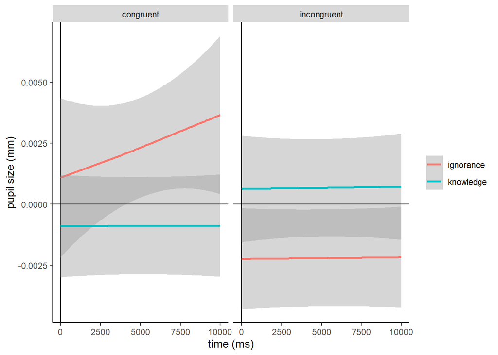

```r
ggplot(multiverse[[2]][[1]], aes(t,baseline,condition, colour =condition)) +
               labs(x = "time (ms)",y = "pupil size (mm)", colour = NULL)+
               geom_vline(xintercept = 0 )+ geom_smooth(se = T) + facet_wrap("outcome") +
               geom_hline(yintercept = 0) +  theme(panel.grid.major = element_blank(), panel.grid.minor = element_blank(),
                                                    panel.background = element_blank(), axis.line = element_line(colour = "black"))
```

At this point, the multiverse object contains a list of three elements, each with a nested structure consisting of two data frames. Each data frame has the same structure but differs in the observations they contain. Here is a breakdown of the structure:

List of 3: The top-level list contains three elements. Each element in this list is itself a list containing two data frames.

Each of the three lists:

Contains two data frames, each having 27 variables (columns). The structure of these data frames is the same, but they have different numbers of observations (rows). //

Third degree of freedom: Participant exclusion (following the criteria of MB2) at the level of the 1st vs 2nd trial.

```r
# Function to remove specific participant IDs from a multiverse
remove_participants <- function(multiverse, ids_to_remove) {
  lapply(multiverse, function(x) {
    lapply(x, function(df) {
      df[!df$participant_id %in% ids_to_remove, ]
    })
  })
}

# Define participant IDs to remove for the second and third multiverse
remove_ids_1 <- c(102, 103, 104, 105)
remove_ids_2 <- c(181, 182, 183, 185)

# Create the three multiverses
multiverse_one <- multiverse
multiverse_two <- remove_participants(multiverse, remove_ids_1)
multiverse_three <- remove_participants(multiverse, remove_ids_2)

# Combine into the megaverse
megaverse <- list(multiverse_one, multiverse_two, multiverse_three)
```

At this point we have an object called megaverse. The megaverse is a comprehensive collection of datasets organized into three different versions, each known as a multiverse. Each multiverse represents a different scenario or variation of the original dataset. Here’s a detailed description of the structure:

Original Multiverse (multiverse_one): This version contains the unaltered original data. It serves as the baseline for comparison with other multiverses. Modified Multiverse 1 (multiverse_two): In this version, certain participants are removed based on a specified list of participant IDs (remove_ids_1). This allows for analyzing how the removal of specific participants affects the results. Modified Multiverse 2 (multiverse_three): This version excludes a different set of participants, defined by another list of participant IDs (remove_ids_2). This provides another perspective on the dataset with a different subset of participants removed. Each multiverse consists of:

A list of lists, where each sublist contains one or more data frames. Each data frame represents a segment of the dataset, including columns such as participant_id and other relevant variables (e.g., score). By structuring the data in this way, the megaverse allows for systematic comparison across different scenarios, facilitating a robust analysis of the dataset under various conditions.

For the analysis of pupillary data, we utilized generalized additive mixed modeling (GAMM, Wood, 2011). GAMMs combine the flexibility of generalized additive models (GAMs) with the ability to incorporate random effects, which are essential for accounting for correlations among observations within clusters or groups. This includes the use of smooth functions that handle both continuous and categorical predictors. The random effects component facilitates the inclusion of hierarchical structures, such as nested or repeated measures within the data, making GAMMs useful for a wide range of data types, including time series, spatial, and longitudinal data. The model is estimated using penalized regression techniques, which help to avoid overfitting and produce more reliable predictions.

```r
library(mgcv)
library(itsadug)
```

```r
library(sjPlot)
library(lme4)
## megaverse <- list(multiverse_one, multiverse_two, multiverse_three)

# Define a function to fit three different linear models to a dataset
fit_models <- function(data) {
  # Model 1: Linear model with condition*outcome
  model1 <- lmer(average ~ condition*outcome + (1|participant_id), data = data)

  # Model 2: Linear model with condition*outcome across the trial time
  model2 <-  lmer(average ~ t*condition*outcome + (1|participant_id), data = data)

  # Model 3: Linear model with both predictor variables 'x1' and 'x2'
  model3 <- bam(baseline~ condition*outcome + s(t, by= lab_id, k=7) + s(t, by= condition, k=20)+ s(t, by= outcome, k=20)+ s(t, participant_id, bs='fs', m=1), data= data, discrete=TRUE,nthreads=40)

  # Store the models in a list
  models <- list(model1 = model1, model2 = model2, model3 = model3)

  return(models)
}
```

## 4. How many and which conditions will participants be assigned to?

Participants are randomly assigned to 1 of 4 conditions. This is done as part of the main MB2-study.

## 5. Specify exactly which analyses you will conduct to examine the main question/hypothesis.

The multiverse forking path of statistical modeling as explain in detail above.

## 6. Any secondary analyses?

In addition to the frequentist analyses, we will run Bayesian analyses for all hypotheses described above since Bayesian analyses allow us to capture evidence for as well as against an effect.

## 7. How many observations will be collected or what will determine the sample size?

This will be determined by the main MB2-analysis. We will include as many observation as are provided by the main study.

## 8. Anything else you would like to pre-register? (e.g., data exclusions, variables collected for exploratory purposes, unusual analyses planned?)

We are going to explore the following additional questions: - Does belief induction (as the mouse changes location in the test trial) increase pupil dilation? - Does belief induction before the outcome relate to changes in pupil dilation after the outcome?

We will run supplementary analyses to investigate whether the overall luminance during testing sessions had an influence on pupil dilation changes.